# Exam 5

## Exam 5

#### Question

1. Alejandro desea saber cuánto aceite se necesita para llenar el depósito cilíndrico interno, pero solamente cuenta con las medidas de las dimensiones que muestra la figura.

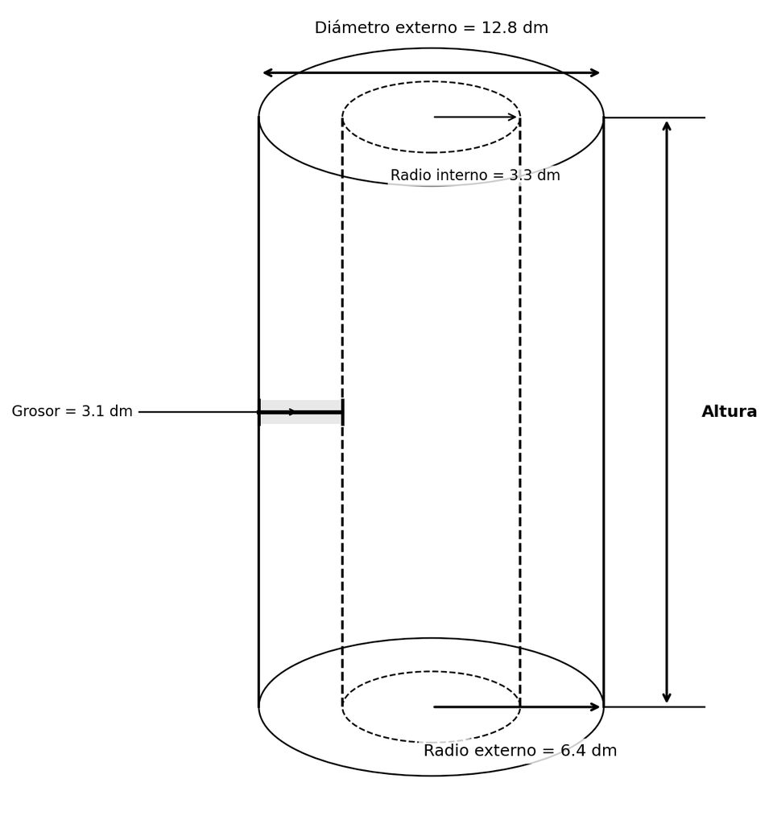

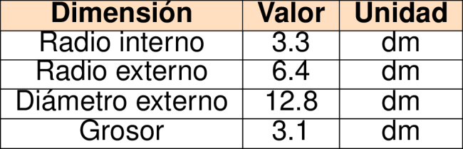

   ¿Cuál medida le falta a Alejandro para hallar la cantidad deseada?
   1. Perímetro del cilindro.
   2. Diámetro externo.
   3. Radio externo.
   4. Altura del cilindro.

#### Solution

   La respuesta correcta es: **Altura del cilindro**.

   Para calcular el volumen de aceite necesario para llenar el depósito cilíndrico interior, necesitamos calcular el volumen de un cilindro, cuya fórmula es:

   $V = \pi \cdot r^2 \cdot h$

   Donde: - $r$ es el radio (en este caso, el radio interno = 3.3 dm) - $h$ es la altura del cilindro

   En el problema se nos proporciona: - Diámetro externo = 12.8 dm - Radio interno = 3.3 dm

   Sin embargo, no se nos proporciona la altura del cilindro, que es esencial para calcular el volumen. Por lo tanto, a Alejandro le falta conocer la altura del cilindro para poder calcular la cantidad de aceite necesaria.

   Si tuviéramos la altura, el volumen se calcularía así: $V = \pi \cdot (3.3)^2 \cdot h = 34.21 \cdot h$ dm³
   1. Falso
   2. Falso
   3. Falso
   4. Verdadero